# GrowthCurve

Philip Sweet

2023-08-30

Goal: Determine the impact of X-ray exposure on growth characteristics of Yarrowia lipolytica WT and yarrowia lipolytica Bx.

Data: Input data is OD600 measurements collected every 20min.

Method: Cells were grwon for 48, exposed to IR using a Faxitron MultiRad 225. High energy particles were selected for with a 0.5mm Al filter. Doses included 0, 2, 50 and 200Gy. The production strain carries a genetically inserted BX operon. Cells were diluted to an OD600 of 0.1 and grown in a BioScreenC culture Honeycomb2 plate at 30C. total volume: 200 uL.

Output: Graphs and summary statistics.

## Data Quality

```r
data %>%
  rownames_to_column(var = "Time2") %>%
  mutate(Time = (((as.numeric(Time2) -1) * time_interval) + 0.05)) %>%
  column_to_rownames(var = "Time2") %>%
  pivot_longer(-Time, values_to = "OD600", names_to = "Well_ID") %>%
   mutate(Well_ID = as.numeric(str_remove(Well_ID, "Well." ))) %>%
  left_join(key, by = c("Well_ID" = "Well_ID")) -> tidy_data

head(tidy_data)
```

```
## # A tibble: 6 × 7
##    Time Well_ID OD600 Strain  Dose BioRep TechRep
##   <dbl>   <dbl> <dbl> <chr>  <int> <chr>    <int>
## 1  0.05     101 0.113 YLWT       0 A            1
## 2  0.05     102 0.113 YLWT       0 A            2
## 3  0.05     103 0.146 YLWT       0 A            3
## 4  0.05     104 0.108 YLWT       0 B            1
## 5  0.05     105 0.12  YLWT       0 B            2
## 6  0.05     106 0.138 YLWT       0 B            3
```

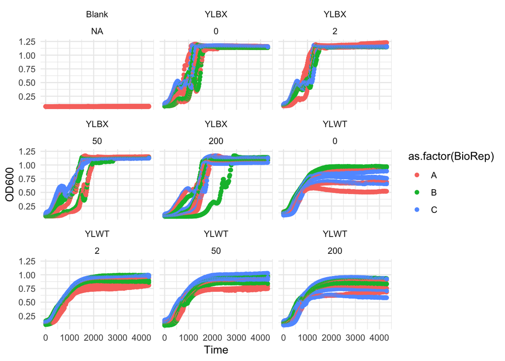

```r
ggplot(tidy_data, aes(x = Time, y = OD600, color = as.factor(BioRep))) +
  geom_point() +
  facet_wrap(~Strain + Dose) +
  theme_minimal()
```

No growth in blank! Growth of the BX strains is highly divergent within biological replicates.

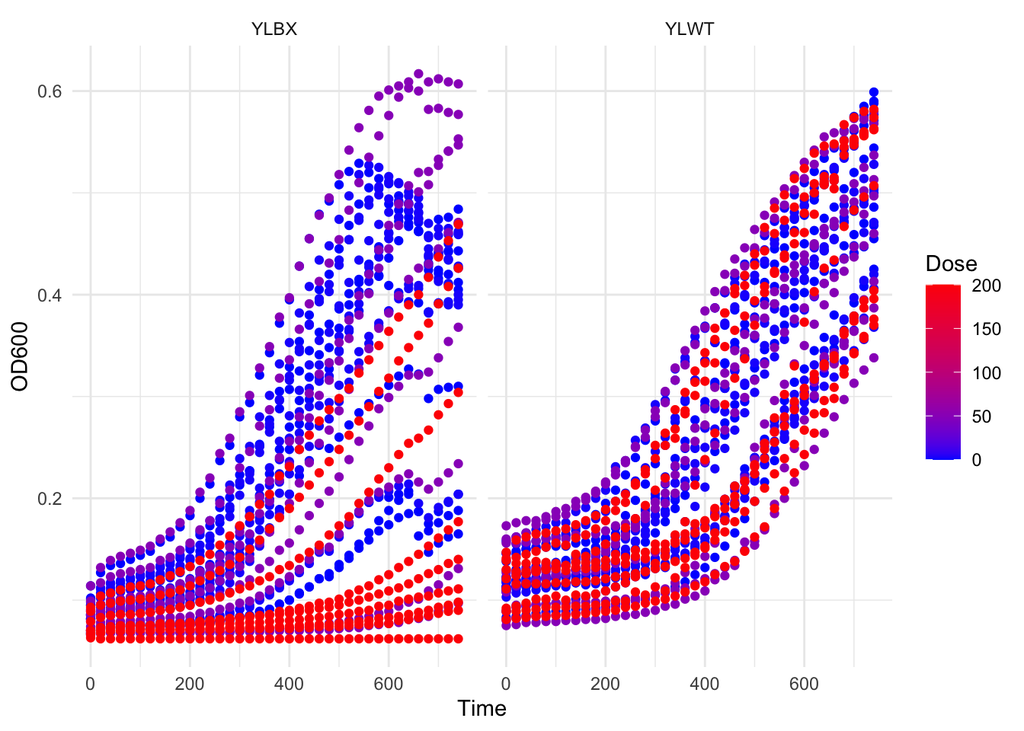

```r
tidy_data %>%
  filter(Strain != "Blank") %>%
  filter(Time < 750 ) %>%
  ggplot(aes(x = Time, y = OD600, color = Dose)) +
    geom_point() +
    scale_color_gradient(low = "blue", high = "red") +
    facet_wrap(~Strain) +
    theme_minimal()
```

Spread in the growth curves, but seems to be more about BioRep than Dose. Bx producing 200Gy do have a lot of growth delays.

```r
all_linear_data <- all_easylinear(OD600 ~  Time | Well_ID + Strain + Dose + BioRep, data = tidy_data)

growthrates <- as.data.frame(coef(all_linear_data ))

growthrates %>%
  rownames_to_column(var = "SampleID") %>%
  separate(SampleID, sep = ":", into = c("Well","Strain","Dose","BioRep")) %>%
  mutate(Dose = as.numeric(Dose)) %>%
  mutate(max_double = (log(2)/mumax)) -> growth_data

growth_data %>%
  group_by(Strain, Dose) %>%
  summarise(mean_minDoubleTime = mean(max_double),
            mean_LagTime = mean(lag))
```

```
## # A tibble: 8 × 4
## # Groups:   Strain [2]
##   Strain  Dose mean_minDoubleTime mean_LagTime
##   <chr>  <dbl>              <dbl>        <dbl>
## 1 YLBX       0               184.         588.
## 2 YLBX       2               129.         462.
## 3 YLBX      50               161.         517.
## 4 YLBX     200               194.         867.
## 5 YLWT       0               190.         215.
## 6 YLWT       2               195.         231.
## 7 YLWT      50               189.         259.
## 8 YLWT     200               176.         289.
```

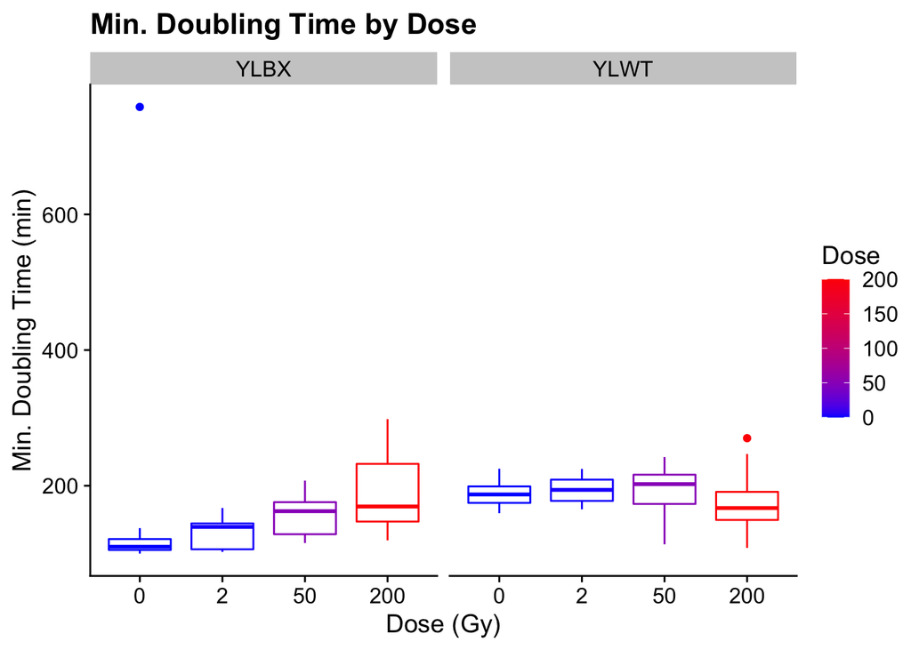

```r
growth_data %>%
  ggplot(aes(x = as.factor(Dose), y = max_double, color = Dose)) +
  geom_boxplot() +
  scale_color_gradient(low = "blue", high = "red") +
  facet_wrap(~Strain)  +
  theme_cowplot()+
  ylab("Min. Doubling Time (min)") +
  xlab("Dose (Gy)") +
  ggtitle("Min. Doubling Time by Dose")
```

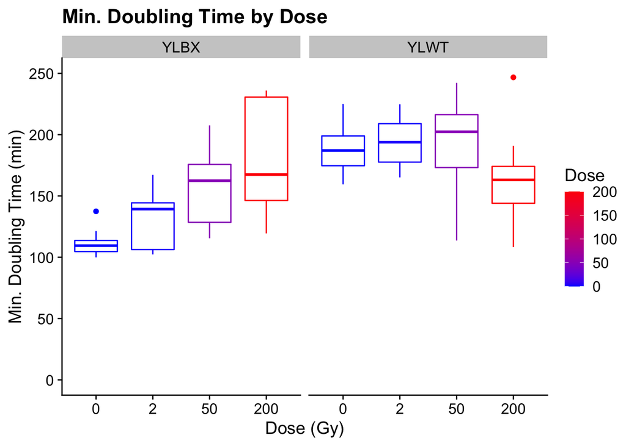

```r
growth_data %>%
  ggplot(aes(x = as.factor(Dose), y = max_double, color = Dose)) +
  geom_boxplot() +
  scale_color_gradient(low = "blue", high = "red") +
  facet_wrap(~Strain)  +
  theme_cowplot()+
  ylab("Min. Doubling Time (min)") +
  xlab("Dose (Gy)") +
  ggtitle("Min. Doubling Time by Dose") +
  ylim(0,250)
```

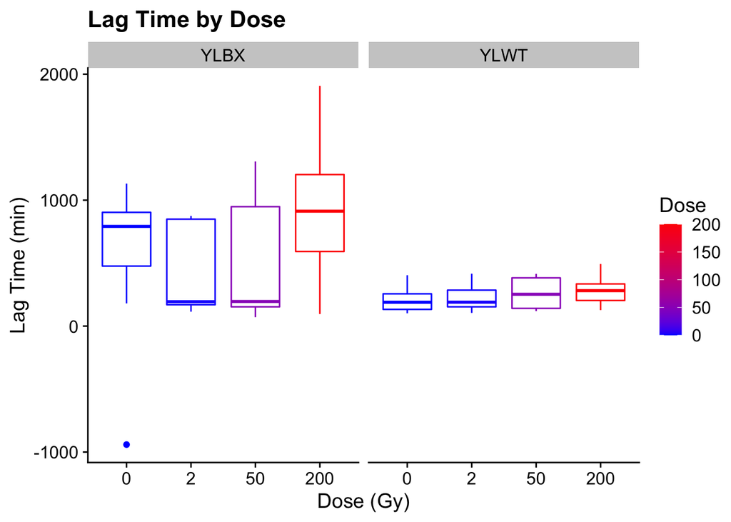

```r
growth_data %>%
  ggplot(aes(x = as.factor(Dose), y = lag, color = Dose)) +
  geom_boxplot() +
  scale_color_gradient(low = "blue", high = "red") +
  facet_wrap(~Strain) +
  theme_cowplot() +
  ylab("Lag Time (min)") +
  xlab("Dose (Gy)") +
  ggtitle("Lag Time by Dose")
```

## Results

Next, lets look at the ratios compared to 0Gy within strains to correct for the difference due to plasmids and production.

```r
growth_data %>%
  group_by(Strain) %>%
  mutate(Ratio_Lag = lag/(mean(lag[Dose == 0]))) %>%
  mutate(Ratio_Max = max_double/(mean(max_double[Dose == 0]))) -> growth_data

growth_data %>%
  group_by(Dose,Strain) %>%
  summarise(
    lag_sd = sd(Ratio_Lag, na.rm = TRUE),
    lag_FC = mean(Ratio_Lag),
    max_sd = sd(Ratio_Max , na.rm = TRUE),
    max_FC = mean(Ratio_Max),
  ) -> summary
```

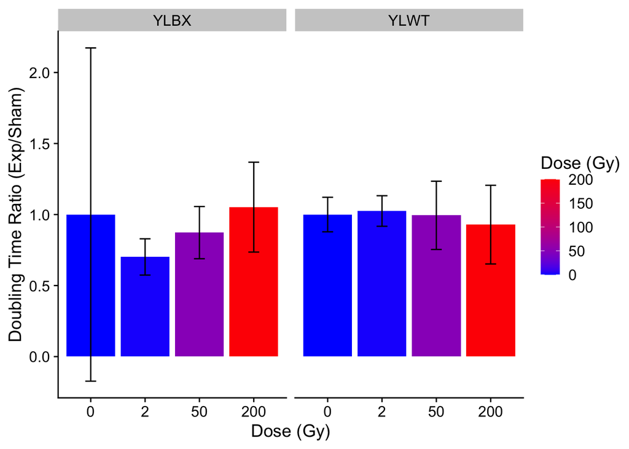

```r
summary %>%
  ggplot(aes(x = as.factor(Dose), max_FC, fill = Dose)) +
  geom_col(position = position_dodge2(preserve = "single")) +
  geom_errorbar(aes(ymin = max_FC - max_sd , ymax = max_FC + max_sd, width = 0.2)) +
  scale_fill_gradient(low = "blue", high = "red") +
  facet_wrap(~Strain) +
  theme_cowplot() +
  labs(fill="Dose (Gy)") +
  xlab("Dose (Gy)") +
  ylab("Doubling Time Ratio (Exp/Sham)")
```

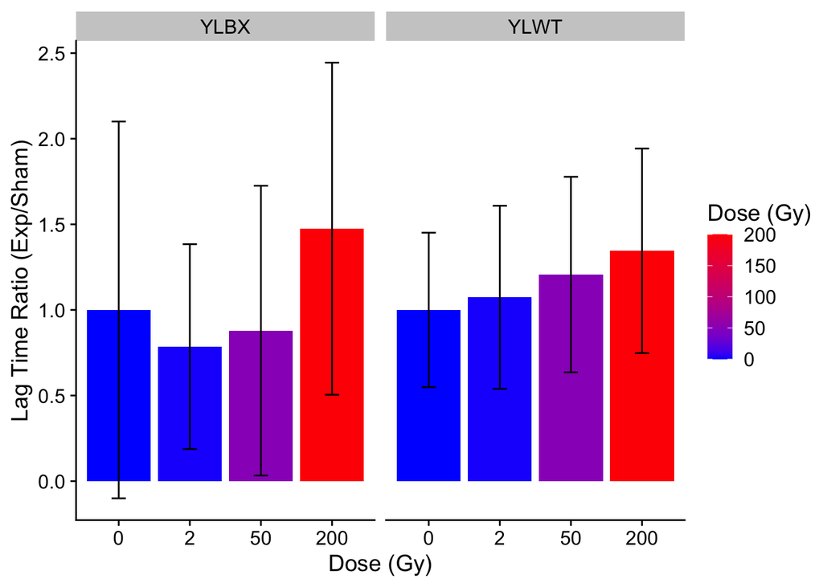

```r
summary %>%
  ggplot(aes(x = as.factor(Dose), lag_FC, fill = Dose)) +
  geom_col(position = position_dodge2(preserve = "single")) +
  geom_errorbar(aes(ymin = lag_FC - lag_sd , ymax = lag_FC + lag_sd, width = 0.2)) +
  scale_fill_gradient(low = "blue", high = "red") +
  facet_wrap(~Strain) +
  theme_cowplot() +
  labs(fill="Dose (Gy)") +
  xlab("Dose (Gy)") +
  ylab("Lag Time Ratio (Exp/Sham)")
```

## Summary

There is no difference in the relative doubling times due to IR, though sham error bars are large complicating statistical testing. The ratio of the lag times are more variable and while there does seem to be an upward trend in the WT after IR exposure, the error bars all overlap.